# FE8828 Assignment for Data

Juilee Save <sub><Email:juilee001@e.ntu.edu.sg></sub>

Dec 2, 2017

# Finding 1

**Customers age vs balance**  
Balance increases slightly with age

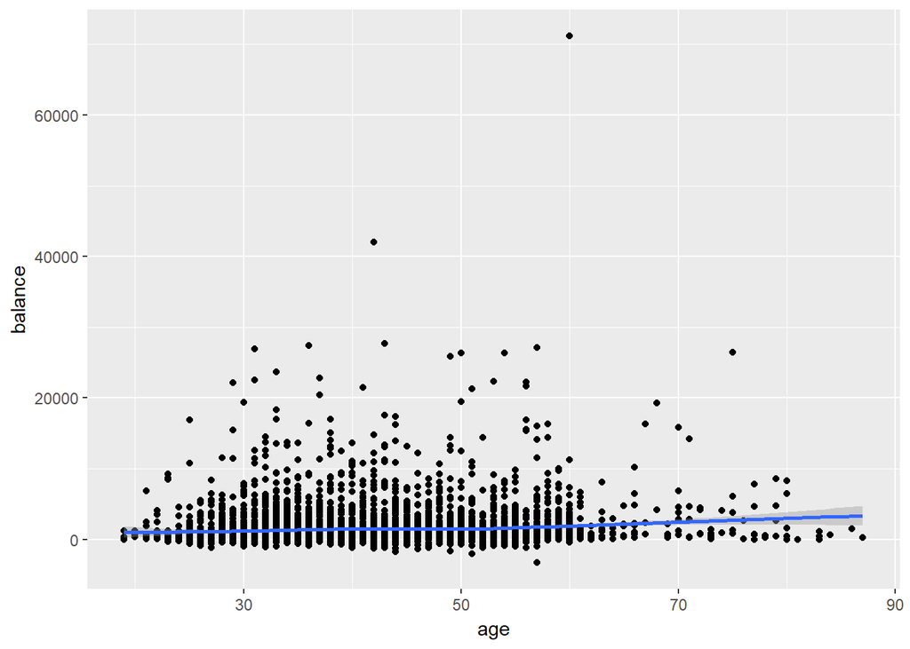

```r
ggplot(bank, aes(age, balance)) +
  geom_point() +
  geom_smooth(method = "loess")
```

# Finding 2

**Customers age vs balance with education as second geometry**  
Balance of customers with tertiary education are more spread out

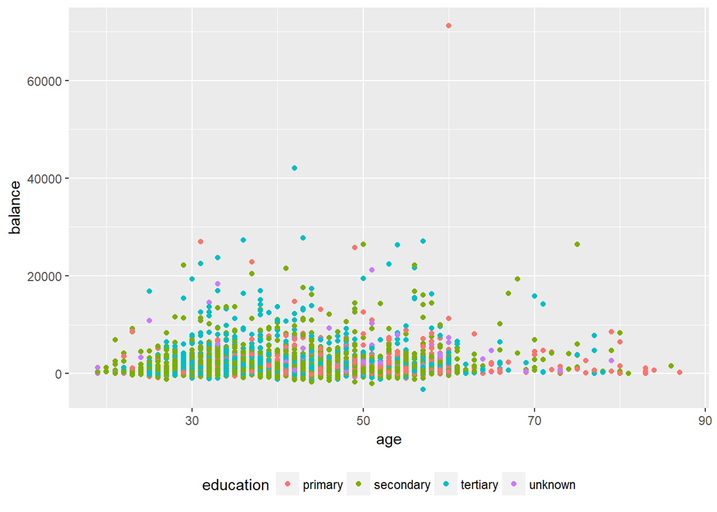

```r
ggplot(bank, aes(age, balance, color = education)) +
  geom_point() +
  theme(legend.position="bottom")
```

# Finding 3

**Boxplot of duration vs type of contact**  
Duration of campaign calls are higher on cellular phones

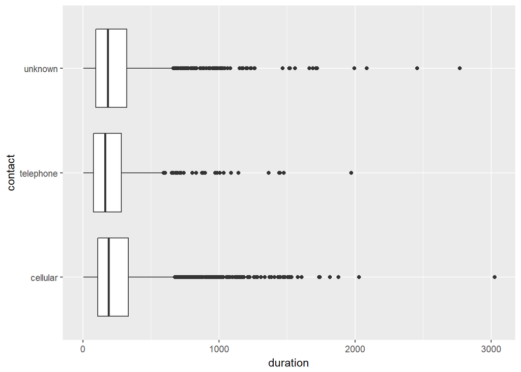

```r
ggplot(bank, aes(contact, duration)) +
  geom_boxplot() +
  coord_flip()
```

# Finding 4

**Bar Graph of jobs grouped by education**  
Management profesionals followed by technicians tend to have tertiary education  
Blue collared and housemaids tend to have primary education

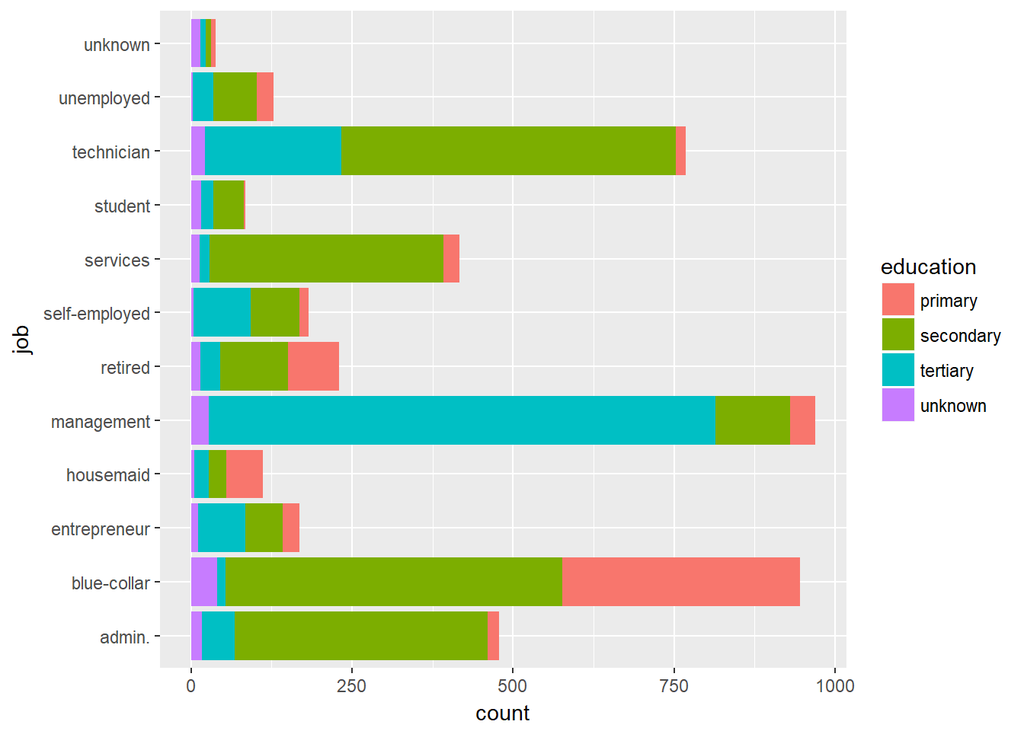

```r
ggplot(data = bank, mapping = aes(x = job, fill = education)) +
  geom_bar() +
  coord_flip()
```

# Finding 5

**Histogram of age grouped by housing**  
The median age group, around 30-45 tends to have more people owning housing

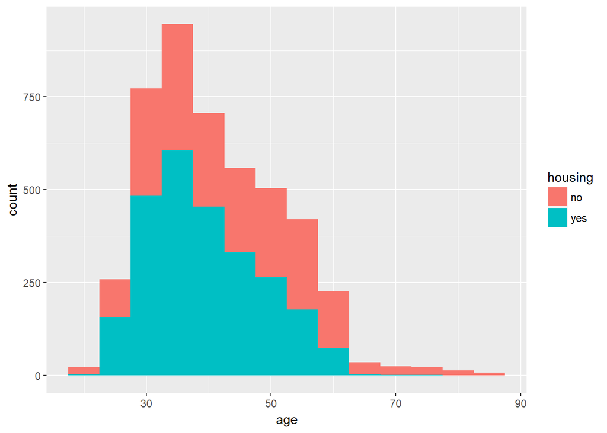

```r
ggplot(bank, mapping = aes(x = age, fill = housing)) +
  geom_histogram(binwidth = 5)
```

# Finding 6

**Density plot of age by education**  
Younger customers tend to be more educated

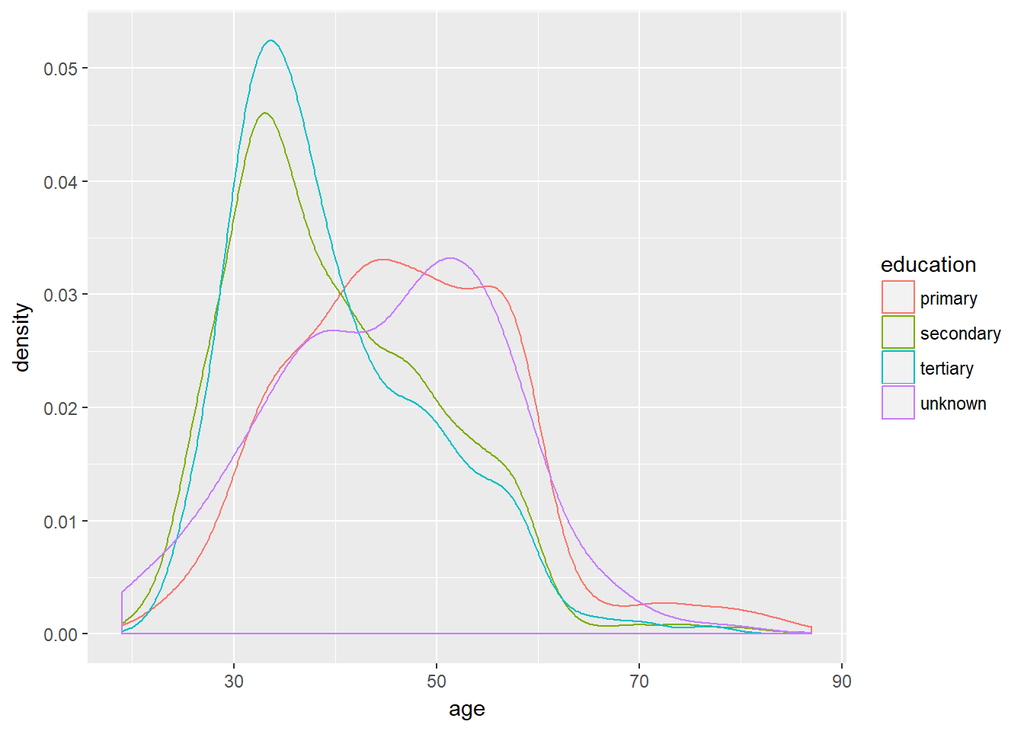

```r
ggplot(bank, aes(age, color = education)) + geom_density()
```

# Finding 7

**Bar plot of age grouped by marital status**  
Percentage of married and divorced people increases with age

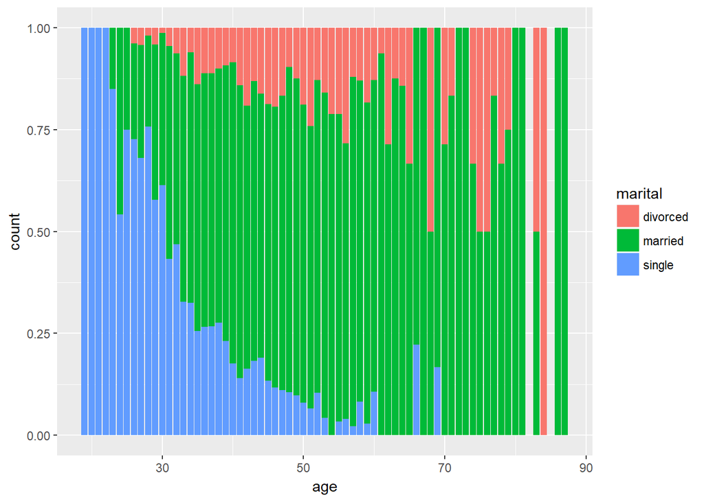

```r
ggplot(bank) +
  geom_bar(mapping = aes(x = age, fill = marital), position = "fill")
```

# Finding 8

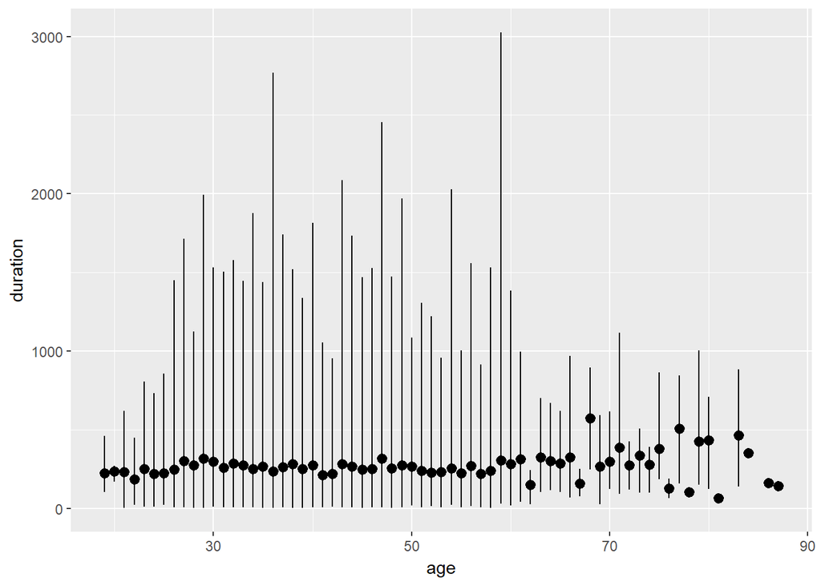

```r
ggplot(data = bank) +
stat_summary(
mapping = aes(x = age, y = duration),
fun.ymin = min,
fun.ymax = max,
fun.y = mean)
```

# Finding 9

**Density of customers subscribing to term deposit by duration of campaign calls**  
Chances of subscribing increase with duration of call

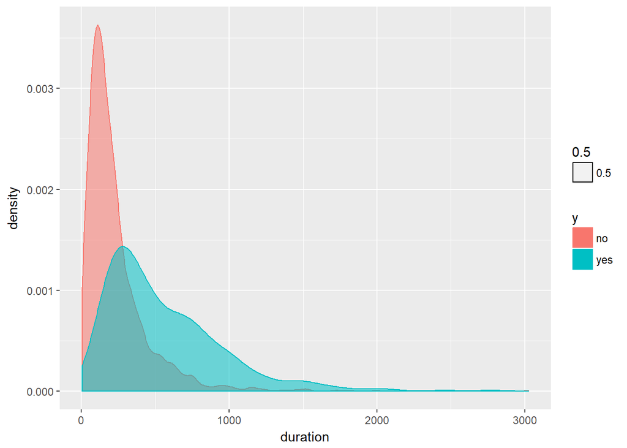

```r
ggplot(bank, aes(duration, color = y, fill = y, alpha = .5)) + geom_density()
```

# Finding 10

**Balance vs age grouped into facets by job**  
Management and technicians tend to have higher balances  
Students are the youngest age group, retired people are the oldest  
Entrepreneurs and retired people have large variations in balance

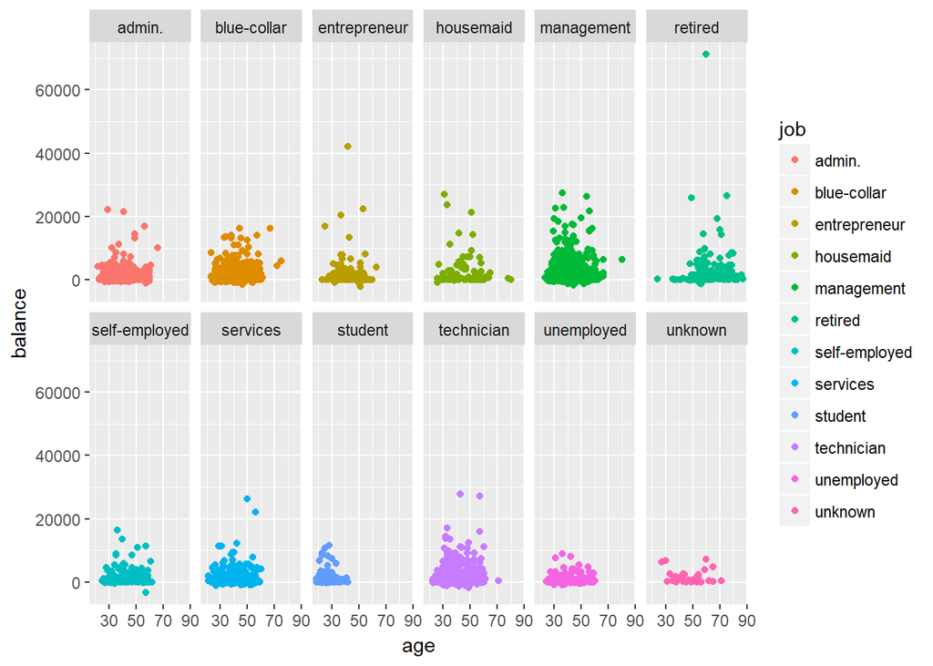

```r
ggplot(data = bank) +
geom_point(mapping = aes(x = age, y = balance, color = job)) +
facet_wrap(~ job, nrow = 2)
```